# Authorship

- Patologların makalelere otör olarak yazılmaması konusunda tartışmalar:

> https://www.facebook.com/groups/1707688912815364/permalink/1967106623540257/

> Bu olayın gerçekle hiç bir ilgili yoktur tamamen kurmacadır.

> Kadın hastalıkları ABD’ından bir grup hekim Sertoli Leydig hücreli tümörlerin prognozu ile ilgili bir çalışma yapmayı planlıyorlar. O hastanede bu hastaların tümünün raporunu yazan patologdan bu hastaların listesini talep ediyorlar. Yazarlar çalışmanın bazı verilerini bu raporlardan elde ediyorlar. Bu aşamadan sonra patologun çalışma ile başka bir ilişkisi olmuyor. Patolog çalışmanın yayınlandığını ve kendi isminin yazarlar arasında yer almadığını daha sonra görüyor. Bu durumda sizce en uygun adım ne olmalı?

Kesin bir sonuca ulaşmak zor. Kafam karışık. Fikir uçuşması şeklinde şunları düşünüyorum:

Sadece hasta listesi elde edildiyse (yaş, cinsiyet, ameliyat tarihi gibi klinik bilgiler kullanıldıysa) bu durumda patoloğun yazılmasına gerek olmayabilir. Ama patoloji disiplinine has veriler kullanılıyorsa patoloğun adının yazılması lazım. Ve çalışmayı o konunun eksper patoloğunun gözetiminde yapmak lazım. Burada etik kaygıdan çok çalışmanın düzgün olmasını önemsiyorum. Sonra kolon tümörlerinde CDX2 ekspresyonuna TMA ile bakıp tümör heterojenitesini göz önüne almayan ya da yeni papiller RCC sınıflamasını göz önüne almadan TCGA çalışması yapıp NEJM’de yayınlatanlar oluyor maalesef :) :)

Hakemler de patoloji ile ilgili kısımlar olduğunda makalenin patolog tarafından gözden geçirilmesini (yazar olarak ya da teşekkür kısmında belirtilerek) istemeli.

Sorunlardan biri de seriyi rapor eden birden fazla patolog varsa hangisinin ismi yazılacak? Diğer patoloğun tanısına katılmayıp seriye vaka katar ya da çıkarırsak ne yapacağız?

Bir de tam tersini düşünelim. Raporlardan bilgileri alıp bir makale yazsalar, patolog hiç vakaları gözden geçirmemiş olsa yine patoloğun ismi yazılmalı mı? Mesela başka patologların tanı verdiği vakalar olsa ve onun değil de başka patoloğun ismi yazılsa?

Peki vakaların yeniden gözden geçirilmesi gerekir mi? İdeal tanılar ile sağkalımı karşılaştırmak mı önemli, yoksa rutin tanılar ile karşılaştırmak mı?

Makale yazmak ve “yazar olmak” ve “belli bir sırada yazar olmak” bir amaç. O yüzden bu tartışma çok su götürür :)

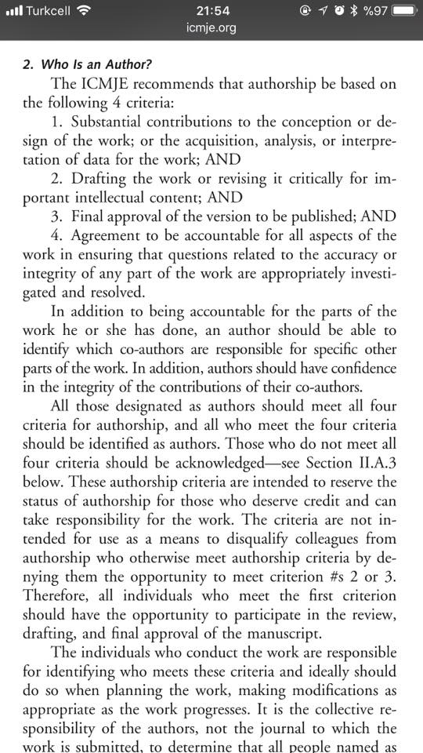

- Assigning authorship for research papers can be tricky. These approaches can help

https://www.sciencemag.org/careers/2018/12/assigning-authorship-research-papers-can-be-tricky-these-approaches-can-help

- Academic promotion policies and equity in global health collaborations

[https://www.thelancet.com/journals/lancet/article/PIIS0140-6736(18)32345-6/fulltext](https://www.thelancet.com/journals/lancet/article/PIIS0140-6736%2818%2932345-6/fulltext)

- Farewell authors, hello contributors

https://www.nature.com/articles/d41586-019-02084-8

- CRediT (Contributor Roles Taxonomy)

is high-level taxonomy, including 14 roles, that can be used to represent the roles typically played by contributors to scientific scholarly output. The roles describe each contributor’s specific contribution to the scholarly output.

https://www.casrai.org/credit.html